# How Certain Is a Joint Component?

rajiveplus package authors

2026-06-10

```r
knitr::opts_chunk$set(
  collapse = TRUE,
  comment = "#>",
  fig.width = 7,
  fig.height = 4.5,
  message = FALSE,
  warning = FALSE
)
```

RaJIVE gives a joint component, but the scientific question begins one step later: how much of that component would survive a new draw of samples? The rank, feature loadings, variance attribution, and phenotype association are all estimates. They can look decisive while still being sample-sensitive.

This vignette uses a small simulated data set to put uncertainty around the main quantities returned by `Rajive()`. The bootstrap counts are intentionally small so the vignette can be checked with the package. Use larger `B` values when intervals are part of a real analysis.

```r
library(rajiveplus)

if (!exists("joint_variance_partition", mode = "function")) {
  pkg_root <- if (file.exists(file.path("..", "DESCRIPTION"))) ".." else "."
  tmp_lib <- tempfile("rajiveplus-lib-")
  dir.create(tmp_lib)
  utils::install.packages(pkg_root, repos = NULL, type = "source",
                          lib = tmp_lib, quiet = TRUE)
  if ("package:rajiveplus" %in% search()) {
    detach("package:rajiveplus", unload = TRUE, character.only = TRUE)
  }
  if ("rajiveplus" %in% loadedNamespaces()) {
    unloadNamespace("rajiveplus")
  }
  .libPaths(c(tmp_lib, .libPaths()))
  library(rajiveplus)
}
```

## A small joint signal

```r
set.seed(101)
n <- 64L
pks <- c(10L, 8L)
sim <- ajive.data.sim(K = 2, rankJ = 1L, rankA = c(1L, 1L),
                      n = n, pks = pks, dist.type = 1)
blocks <- sim$sim_data
names(blocks) <- c("rna", "protein")
for (k in seq_along(blocks)) {
  rownames(blocks[[k]]) <- paste0("sample", seq_len(n))
  colnames(blocks[[k]]) <- paste0(names(blocks)[[k]], "_", seq_len(ncol(blocks[[k]])))
}

fit <- Rajive(blocks, initial_signal_ranks = c(2L, 2L),
              joint_rank = 1L,
              n_wedin_samples = NA,
              n_rand_dir_samples = NA,
              seed = 101L)

stopifnot(inherits(fit, "rajive"))
stopifnot(fit$joint_rank == 1L)
```

## Where does each feature’s variance go?

Each feature can carry shared signal, block-specific signal, and residual variation at the same time. `joint_variance_partition()` makes that accounting explicit by assigning the feature-level sum of squares to joint, individual, and residual terms. The residual is computed after reconstructing the fitted joint and individual matrices, so the original data blocks are supplied with the fit.

```r
vp <- joint_variance_partition(fit, blocks)
head(vp)
```

```
#>   feature block   joint_ss individual_ss residual_ss component_total_ss
#> 1   rna_1   rna 16.6656919     22.613570    54.01271           93.29197
#> 2   rna_2   rna  2.0391926      7.825723    47.34075           57.20567
#> 3   rna_3   rna 40.9700615      9.844709    50.55505          101.36982
#> 4   rna_4   rna  0.3305673     12.283096    81.25319           93.86685
#> 5   rna_5   rna  1.1957834     47.177432    55.26645          103.63967
#> 6   rna_6   rna  1.4005989      5.866200    47.49643           54.76323
#>   data_total_ss  joint_prop individual_prop residual_prop reconstruction_error
#> 1      86.94306 0.178640154      0.24239567     0.5789642            6.3489098
#> 2      58.84075 0.035646689      0.13679980     0.8275535            1.6350877
#> 3     101.66314 0.404164280      0.09711676     0.4987190            0.2933207
#> 4      98.68559 0.003521662      0.13085659     0.8656217            4.8187434
#> 5     100.16872 0.011537893      0.45520632     0.5332558            3.4709519
#> 6      55.08271 0.025575534      0.10711931     0.8673052            0.3194780
```

```r
stopifnot(all(c("joint_prop", "individual_prop", "residual_prop") %in% names(vp)))
stopifnot(all(is.finite(vp$joint_prop)))
```

## Which loadings are stable?

Loadings are the bridge from a latent component back to biology, but they are not fixed constants. They depend on the samples used to fit the model. The bootstrap below refits RaJIVE, aligns each refit to the full-data loading matrix, and then forms entry-wise intervals. When components are nearly tied, read these intervals as summaries of directions or subspaces, not as isolated coefficient certainties.

```r
set.seed(102)
ci_load <- rajive_ci(fit, blocks, c(2L, 2L),
                     target = "loadings",
                     method = "percentile",
                     B = 20L,
                     joint_rank = 1L,
                     n_wedin_samples = NA,
                     n_rand_dir_samples = NA,
                     seed = 102L)

load_tbl <- extract_components(fit, what = "loadings",
                               format = "long", ci = ci_load)
head(load_tbl)
```

```
#>   block  type component feature     loading       lower       upper level
#> 1     1 joint         1       1 -0.18523445 -0.15801838 -0.15801838  0.95
#> 2     1 joint         1       2 -0.06479466 -0.09594815 -0.09594815  0.95
#> 3     1 joint         1       3  0.29043129  0.28973453  0.28973453  0.95
#> 4     1 joint         1       4 -0.02608796 -0.01797186 -0.01797186  0.95
#> 5     1 joint         1       5  0.04961767  0.05122564  0.05122564  0.95
#> 6     1 joint         1       6 -0.05369910 -0.15539507 -0.15539507  0.95
#>    ci_method n_replicates
#> 1 percentile           20
#> 2 percentile           20
#> 3 percentile           20
#> 4 percentile           20
#> 5 percentile           20
#> 6 percentile           20
```

```r
stopifnot(all(c("lower", "upper", "ci_method") %in% names(load_tbl)))
```

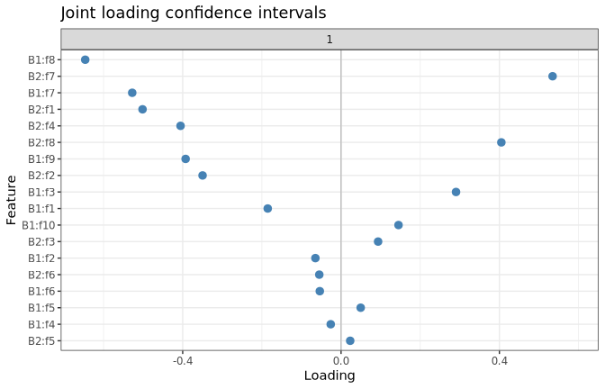

```r
p_load <- plot_components(fit, plot_type = "loading_ci", ci = ci_load,
                          top_n = 25L)
print(p_load)
```

## How stable is the rank?

The joint rank is also estimated. A percentile interval reports the bootstrap distribution directly. A BCa interval adds a jackknife estimate of acceleration: one sample is left out at a time, or one cluster at a time when clusters are supplied. The extra information costs extra refits.

```r
set.seed(103)
ci_rank <- rajive_ci(fit, blocks, c(2L, 2L),
                     target = "joint_rank",
                     method = "bca",
                     B = 20L,
                     joint_rank = 1L,
                     n_wedin_samples = NA,
                     n_rand_dir_samples = NA,
                     seed = 103L)
ci_rank
```

```
#>       target block component feature sample estimate lower upper level method
#> 1 joint_rank  <NA>        NA    <NA>   <NA>        1     1     1  0.95    bca
#>   n_replicates
#> 1           20
```

```r
stopifnot(ci_rank$method == "bca")
stopifnot(is.finite(ci_rank$lower), is.finite(ci_rank$upper))
```

## Do associations survive refitting?

Associations between component scores and metadata attach phenotype to a latent axis, but they condition on estimated scores. With `propagate_uncertainty = "bootstrap"`, `associate_components()` keeps the usual point-estimate p value and adds refit-based summaries: the fraction of significant refits, an effect-size interval, the median bootstrap p value, and the number of valid refits behind the row.

```r
set.seed(104)
metadata <- data.frame(marker = fit$joint_scores[, 1L] + rnorm(n, sd = 0.05))

assoc <- associate_components(
  fit, metadata,
  variable = "marker",
  mode = "continuous",
  propagate_uncertainty = "bootstrap",
  blocks = blocks,
  initial_signal_ranks = c(2L, 2L),
  B = 20L,
  joint_rank = 1L,
  n_wedin_samples = NA,
  n_rand_dir_samples = NA,
  seed = 104L
)
assoc
```

```
#>   variable component      stat      p_value        p_adj  method stability
#> 1   marker         1 0.9527497 8.728067e-34 8.728067e-34 pearson         1
#>   effect_lo effect_hi     p_median p_adj_median n_boot_valid
#> 1 0.9345769 0.9518614 2.786442e-17 2.786442e-17           20
```

```r
stopifnot(all(c("stability", "effect_lo", "effect_hi", "p_median",
                "n_boot_valid") %in% names(assoc)))
```

To screen the whole decomposition, `associate_all_components()` keeps joint and block-specific individual score families separate. Bootstrap replicates are aligned to each family’s full-data basis, so individual-component summaries are basis-conditional sensitivity checks rather than formal post-selection inference.

```r
set.seed(105)
metadata_i <- data.frame(marker = fit$block_decomps[[1L]]$u[, 1L] +
                           rnorm(n, sd = 0.05))

assoc_all <- associate_all_components(
  fit, metadata_i,
  variable = "marker",
  mode = "continuous",
  include = "both",
  blocks_to_include = 1L,
  propagate_uncertainty = "bootstrap",
  blocks = blocks,
  initial_signal_ranks = c(2L, 2L),
  B = 6L,
  joint_rank = 1L,
  n_wedin_samples = NA,
  n_rand_dir_samples = NA,
  seed = 105L
)
assoc_all
```

```
#>       source block variable component       stat      p_value        p_adj
#> 1      joint    NA   marker         1 0.02261495 8.592127e-01 8.592127e-01
#> 2 individual     1   marker         1 0.95231849 1.149312e-33 2.298623e-33
#>    method stability  effect_lo  effect_hi     p_median p_adj_median
#> 1 pearson         0 -0.1064348 0.03939159 8.118121e-01 8.118121e-01
#> 2 pearson         1  0.9526254 0.96284199 1.020706e-20 2.041413e-20
#>   n_boot_valid
#> 1            6
#> 2            6
```

```r
stopifnot(all(c("source", "block", "stability", "n_boot_valid") %in%
                names(assoc_all)))
```

The association table has two useful views: an adjusted-p-value heatmap for the scan, and an uncertainty forest for the point effect, bootstrap interval, stability, and valid-refit count.

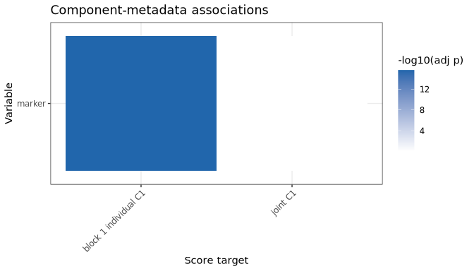

```r
p_assoc <- plot_components(assoc_results = assoc_all,
                           plot_type = "association")
print(p_assoc)
```

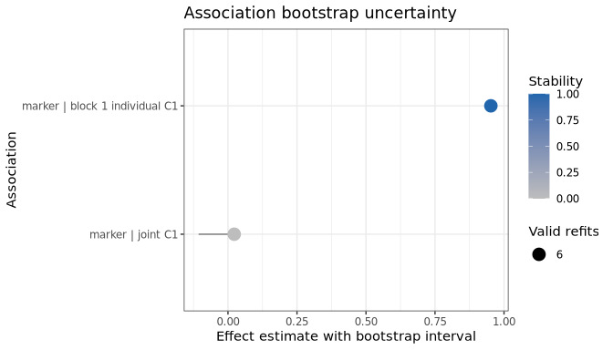

```r
p_unc <- plot_components(assoc_results = assoc_all, plot_type = "association",
                         style = "uncertainty")
print(p_unc)
```